# Topic 1 Exercises

## Ilse Dippenaar

### 2.4.1

#### a)

A flexible model would perform better in this situation since the higher flexibility can minimize the bias by capturing the effect of all the predictors while also not suffering from high variance due to the number of observations.

#### b)

An inflexible model would be superior in this case since there is a great risk for overfitting with fewer data points.

#### c)

A more flexible model would be better here since more flexibility can capture non-linear relationships more accurately.

#### d)

Less flexibile models would be less prone to overfitting the data given the high irreducible error (inflexible models would not mistake random noise for actual relationships).

### 2.4.3

#### a)

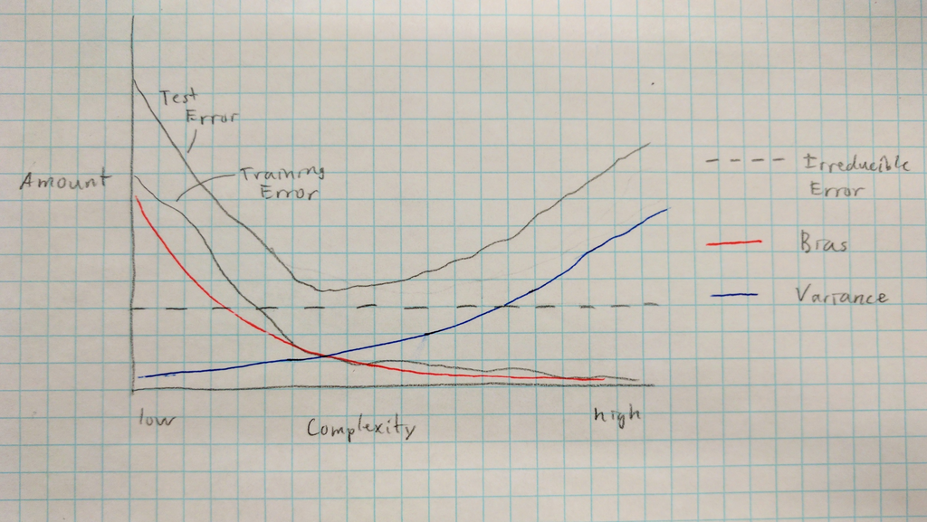

#### b)

The irreducible error stays constant since it is inherent to the system being measured. The bias curve decreases since the model can assume less as its complexity increases, while the variance increases with model complexity since small changes in the data can create large changes in the model response. The training error decreases monotonically as model complexity increases. Higher complexity provides a super set of available options for the model, and eventually the model can completely overfit the training data until there is no training error remaining. However, the test error does not decrease monotonically and its expected value can never be less than the irreducible error. As the model begins to overfit the data, the testing error will increase.

### 2.4.6

A parametric regression approach reduces relationships between predictors and response variables to a set of parameters (i.e. coefficients), while a non-parametric approach allows for a greater fit to the data by relaxing any assumption about the form of $f$. However, the higher flexibility requires much more data to provide accurate predictions than the less flexible parametric methods.

### 2.4.8

#### a-b)

```r
library(mosaic)
library(ISLR)
# The College dataset in ISLR already has row names set
```

#### c)

```r
summary(College)
```

```
##  Private        Apps           Accept          Enroll       Top10perc
##  No :212   Min.   :   81   Min.   :   72   Min.   :  35   Min.   : 1.00
##  Yes:565   1st Qu.:  776   1st Qu.:  604   1st Qu.: 242   1st Qu.:15.00
##            Median : 1558   Median : 1110   Median : 434   Median :23.00
##            Mean   : 3002   Mean   : 2019   Mean   : 780   Mean   :27.56
##            3rd Qu.: 3624   3rd Qu.: 2424   3rd Qu.: 902   3rd Qu.:35.00
##            Max.   :48094   Max.   :26330   Max.   :6392   Max.   :96.00
##    Top25perc      F.Undergrad     P.Undergrad         Outstate
##  Min.   :  9.0   Min.   :  139   Min.   :    1.0   Min.   : 2340
##  1st Qu.: 41.0   1st Qu.:  992   1st Qu.:   95.0   1st Qu.: 7320
##  Median : 54.0   Median : 1707   Median :  353.0   Median : 9990
##  Mean   : 55.8   Mean   : 3700   Mean   :  855.3   Mean   :10441
##  3rd Qu.: 69.0   3rd Qu.: 4005   3rd Qu.:  967.0   3rd Qu.:12925
##  Max.   :100.0   Max.   :31643   Max.   :21836.0   Max.   :21700
##    Room.Board       Books           Personal         PhD
##  Min.   :1780   Min.   :  96.0   Min.   : 250   Min.   :  8.00
##  1st Qu.:3597   1st Qu.: 470.0   1st Qu.: 850   1st Qu.: 62.00
##  Median :4200   Median : 500.0   Median :1200   Median : 75.00
##  Mean   :4358   Mean   : 549.4   Mean   :1341   Mean   : 72.66
##  3rd Qu.:5050   3rd Qu.: 600.0   3rd Qu.:1700   3rd Qu.: 85.00
##  Max.   :8124   Max.   :2340.0   Max.   :6800   Max.   :103.00
##     Terminal       S.F.Ratio      perc.alumni        Expend
##  Min.   : 24.0   Min.   : 2.50   Min.   : 0.00   Min.   : 3186
##  1st Qu.: 71.0   1st Qu.:11.50   1st Qu.:13.00   1st Qu.: 6751
##  Median : 82.0   Median :13.60   Median :21.00   Median : 8377
##  Mean   : 79.7   Mean   :14.09   Mean   :22.74   Mean   : 9660
##  3rd Qu.: 92.0   3rd Qu.:16.50   3rd Qu.:31.00   3rd Qu.:10830
##  Max.   :100.0   Max.   :39.80   Max.   :64.00   Max.   :56233
##    Grad.Rate
##  Min.   : 10.00
##  1st Qu.: 53.00
##  Median : 65.00
##  Mean   : 65.46
##  3rd Qu.: 78.00
##  Max.   :118.00
```

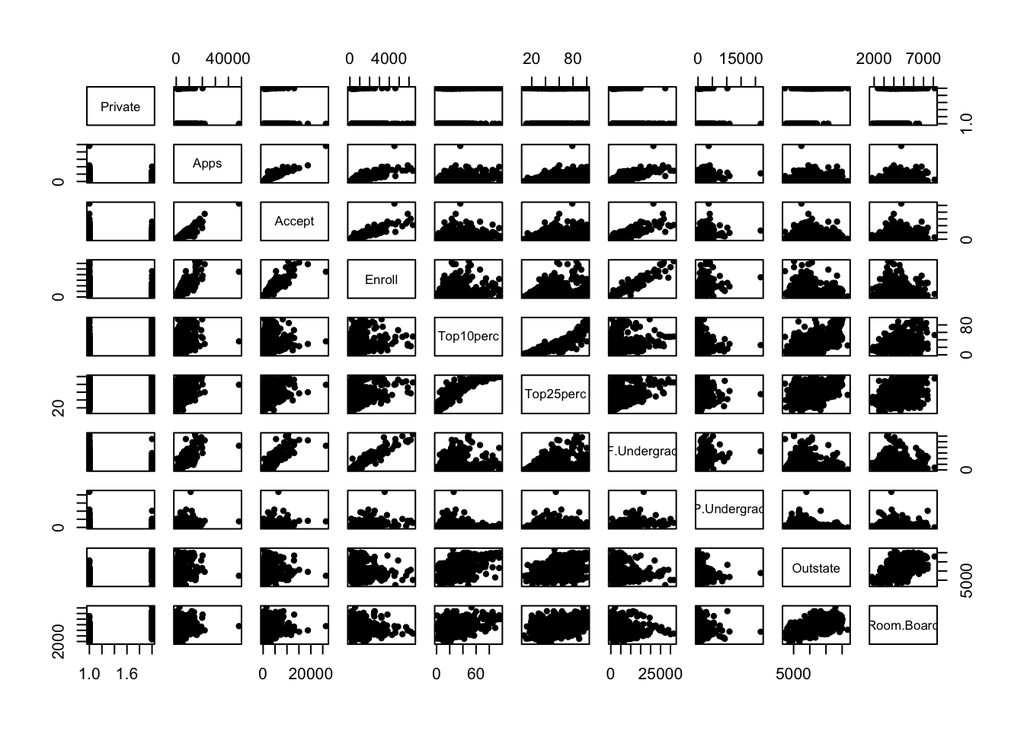

```r
pairs(College[,1:10], pch=20)
```

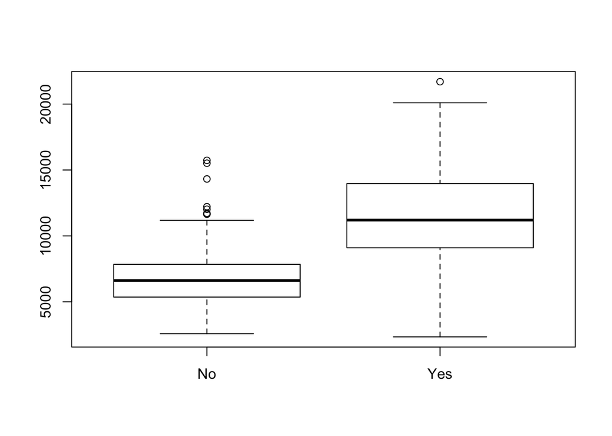

```r
with(College, plot(Private, Outstate))
```

```r
Elite <- rep("No",nrow(College))
Elite[College$Top10perc >50]="Yes"
Elite <- as.factor(Elite)
College=data.frame(College ,Elite)
summary(College$Elite)
```

```
##  No Yes
## 699  78
```

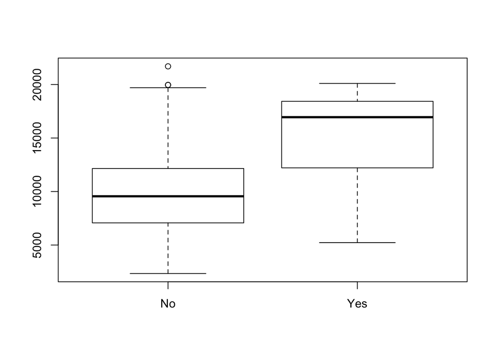

```r
with(College, plot(Elite, Outstate))
```

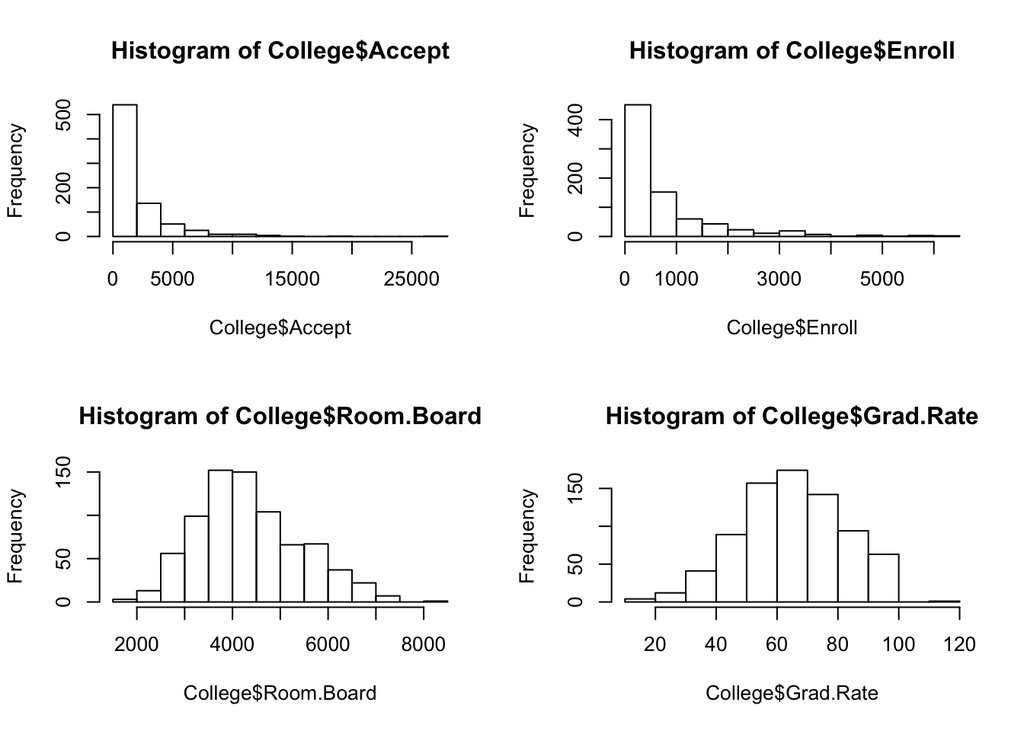

```r
par(mfrow = c(2,2))
hist(College$Accept)
hist(College$Enroll)
hist(College$Room.Board)
hist(College$Grad.Rate)
```

```r
with(College, t.test(Room.Board~Private))
```

```
##
##  Welch Two Sample t-test
##
## data:  Room.Board by Private
## t = -11.222, df = 478.09, p-value < 2.2e-16
## alternative hypothesis: true difference in means is not equal to 0
## 95 percent confidence interval:
##  -984.6203 -691.1853
## sample estimates:
##  mean in group No mean in group Yes
##          3748.241          4586.143
```

```r
with(College, sd(Room.Board~Private))
```

```
##        No       Yes
##  858.1399 1089.6976
```

```r
with(College, t.test(Top10perc~Private))
```

```
##
##  Welch Two Sample t-test
##
## data:  Top10perc by Private
## t = -4.8433, df = 415.34, p-value = 1.806e-06
## alternative hypothesis: true difference in means is not equal to 0
## 95 percent confidence interval:
##  -9.132558 -3.859578
## sample estimates:
##  mean in group No mean in group Yes
##          22.83491          29.33097
```

There is a significant difference in cost and in percentage of new students from the top 10% of high school between private and public colleges. Even though the difference in means is significant, there is still high amounts of variability in the cost of college, especially for private colleges.

### 2.4.9

#### a)

All the columns in `Auto` are quantitiave except `cyliners`, which is qualitative. The `name` column constitutes neither quantitative or qualitative observations.

#### b)

```r
Auto.quant_names <- names(Auto)[!names(Auto) %in% c("cylinders", "name")]
vapply(Auto.quant_names,
       function(name) range(Auto[[name]]),
       numeric(2))
```

```
##       mpg displacement horsepower weight acceleration year origin
## [1,]  9.0           68         46   1613          8.0   70      1
## [2,] 46.6          455        230   5140         24.8   82      3
```

#### c)

```r
temp <- vapply(Auto.quant_names,
       function(name) c(mean(Auto[[name]]), sd(Auto[[name]])),
       numeric(2))
rownames(temp) <- c("mean", "sd")
temp
```

```
##            mpg displacement horsepower    weight acceleration      year
## mean 23.445918      194.412  104.46939 2977.5842    15.541327 75.979592
## sd    7.805007      104.644   38.49116  849.4026     2.758864  3.683737
##         origin
## mean 1.5765306
## sd   0.8055182
```

#### d)

```r
Auto.mod <- Auto[-(10:85)]
temp <- vapply(Auto.quant_names,
       function(name) c(range(Auto.mod[[name]]),
                        mean(Auto.mod[[name]]),
                        sd(Auto.mod[[name]])),
       numeric(4))
rownames(temp) <- c("low", "high", "mean", "sd")
temp
```

```
##            mpg displacement horsepower    weight acceleration      year
## low   9.000000       68.000   46.00000 1613.0000     8.000000 70.000000
## high 46.600000      455.000  230.00000 5140.0000    24.800000 82.000000
## mean 23.445918      194.412  104.46939 2977.5842    15.541327 75.979592
## sd    7.805007      104.644   38.49116  849.4026     2.758864  3.683737
##         origin
## low  1.0000000
## high 3.0000000
## mean 1.5765306
## sd   0.8055182
```

#### e)

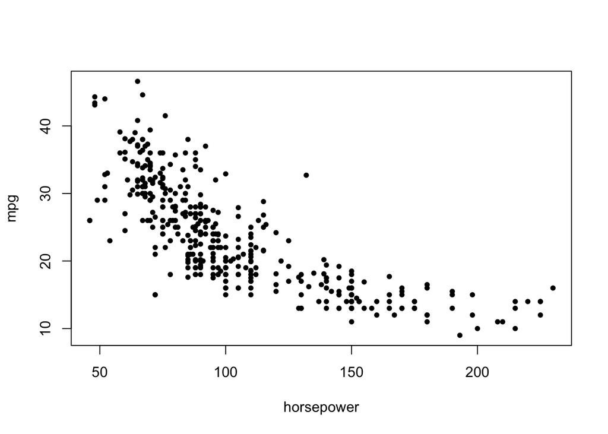

```r
with(Auto, plot(horsepower, mpg, pch=20))
```

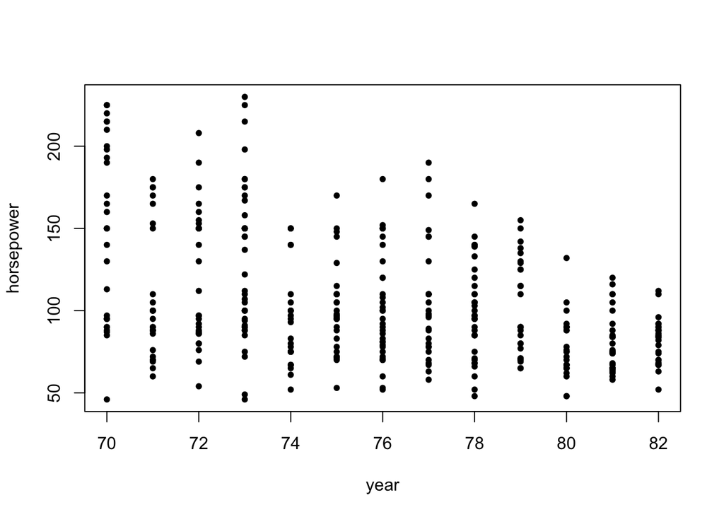

```r
with(Auto, plot(year, horsepower, pch=20))
```

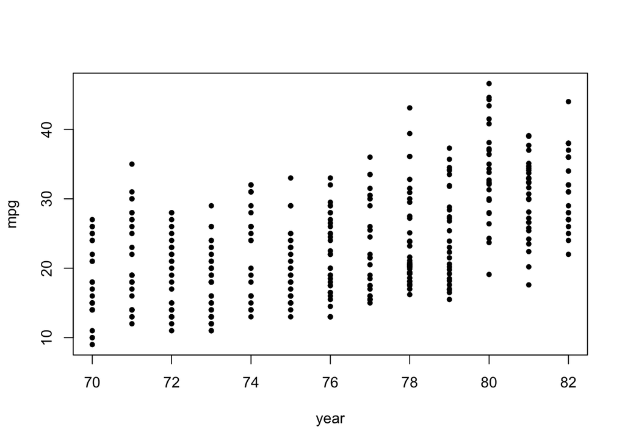

```r
with(Auto, plot(year, mpg, pch=20))
```

#### f)

```r
summary(with(Auto, lm(mpg~year)))
```

```
##
## Call:
## lm(formula = mpg ~ year)
##
## Residuals:
##      Min       1Q   Median       3Q      Max
## -12.0212  -5.4411  -0.4412   4.9739  18.2088
##
## Coefficients:
##              Estimate Std. Error t value Pr(>|t|)
## (Intercept) -70.01167    6.64516  -10.54   <2e-16 ***
## year          1.23004    0.08736   14.08   <2e-16 ***
## ---
## Signif. codes:  0 '***' 0.001 '**' 0.01 '*' 0.05 '.' 0.1 ' ' 1
##
## Residual standard error: 6.363 on 390 degrees of freedom
## Multiple R-squared:  0.337,  Adjusted R-squared:  0.3353
## F-statistic: 198.3 on 1 and 390 DF,  p-value: < 2.2e-16
```

```r
summary(with(Auto, lm(horsepower~year)))
```

```
##
## Call:
## lm(formula = horsepower ~ year)
##
## Residuals:
##     Min      1Q  Median      3Q     Max
## -84.484 -25.455  -6.478  23.980 112.568
##
## Coefficients:
##             Estimate Std. Error t value Pr(>|t|)
## (Intercept) 435.0215    36.5936  11.888   <2e-16 ***
## year         -4.3505     0.4811  -9.044   <2e-16 ***
## ---
## Signif. codes:  0 '***' 0.001 '**' 0.01 '*' 0.05 '.' 0.1 ' ' 1
##
## Residual standard error: 35.04 on 390 degrees of freedom
## Multiple R-squared:  0.1734, Adjusted R-squared:  0.1712
## F-statistic: 81.79 on 1 and 390 DF,  p-value: < 2.2e-16
```

### 2.4.2

#### a)

This is an inferential regression problem. $n=500$ and $p=3$.

#### b)

This ia a predictive classification problem. $n=20$ and $p=13$.

#### c)

This is a predictive regression problem. $n=52$ and $p=3$.

### 2.4.7

#### a)

```r
A <- rbind(c(0,2,0,0,-1,1), c(3,0,1,1,0,1), c(0,0,3,2,1,1))
colnames(A) <- c("red", "red", "red", "green", "green", "red")
sort(apply(A, 2, function(v) sqrt(sum(v^2))))
```

```
##    green      red      red    green      red      red
## 1.414214 1.732051 2.000000 2.236068 3.000000 3.162278
```

#### b)

The prediction will be green since the closest point is green.

#### c)

The prediction will be red since 2 of the 3 closest points are red.

#### d)

We would expect $K$ to be small since smaller $K$ allows KNN to be more flexible, and thus create a more non-linear Bayes decision boundary.